# How to open files

sila

You can read data into R from the interface or by using commands. First I will explain how to add the data using the GUI and then how to code it.

[figure not shown]

Fig. Import dataset

Then you can choose the type of data you want to load in. CSV files are text files so treat them as such.A window will pop in where you will be able to choose a file of your choice.

Then press import and change the settings according to your liking. If your data has headings then make sure you are marking it in settings.

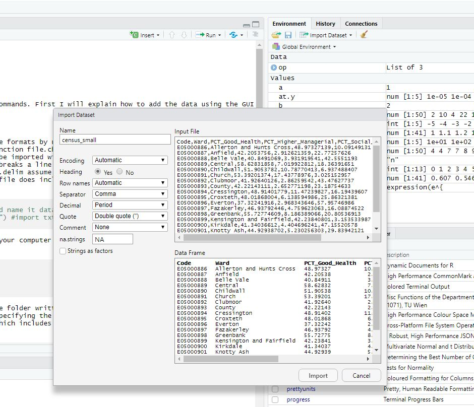

Fig. Import dataset

You can read data into R from many different types of file formats by using an appropriate read function. For example, to open a csv file, use read.csv. You can then use the function file.choose inside read.csv to open a browser and navigate to your dataset. Files with a txt extension can be imported with the generic read.table function, but here you have to specify the field separator – the character that breaks a line into columns. The read.delim function reads in tab-delimited txt files. By default the read.csv and read.delim assume that variable names are included in the dataset, but read.table assumes that they are not. Thus, if a txt file does include variable names in the first row, you also have to set header=TRUE when using read.table.

```r
data_csv <- read.csv(file.choose()) #import a csv file and name it data_csv
data_txt <- read.table(file.choose(), header=TRUE, sep=";") #import txt file
```

R is always associated with a directory (i.e. folder) on your computer – this is your working directory. You can find out what your working directory is by running

```r
getwd() # with no arguments.

getwd() #get working directory - I hope it works
```

To set a working directory use setwd, with the path to the folder written out inside quotation marks as in the example below. You can then read in data from that directory by specifying the dataset name inside read.csv. The following example imports the dataset Carstairs_scores_DZ2011.csv which includes data on the Carstairs deprivation score for datazones based on the 2011 Scottish Census.

```r
setwd("H:/.../Data") #set working directory - chose a place that you like.
```

You can press “shift+ctrl + right click” on the folder you want the directory to be in and copy it as path. Once you do it you should paste the patrh inbetween the brackets in the setwd(…). Remember that you have to add change to / in order for R to read the data in.

Once your working directory is set and you have your data in the same place where your R file is you should be able to read a file in just by calling its name.

```r
d_dep <- read.csv("Carstairs_scores_DZ2011.csv") #read in data
```

```r
# list the path to data within read function
d_ur <- read.table(".../Data/DZ2001_SGUR2011_2012_Lookup.txt",
header=TRUE, sep=",")
```

After importing a dataset you should see it listed in the Environment pane top right, the name of the dataset in R should be listed together with the number of observations and variables in the dataset.

[output not shown]